# Dividend Discovery

Author

Rick Dean

Abstract

The following notes/R scripts were inspired from an article [Dividend Discovery](http://www.reproduciblefinance.com/2019/07/10/dividend-discovery/) by Jonathan Regenstein.

```r
library(data.table)
library(magrittr)
library(quantmod)
library(ggplot2)
library(RplotterPkg)
library(RstocksPkg)
```

Be aware that this application has an internet request for dividend data that will take time to complete.

# 1 Dividend Discovery

## 1.1 The data

Get the ticker symbols for companies in the Dow Industrial Average Index(DOW30).

```r
DOW_30_tickers <- RstocksPkg::get_dow30_symbols()
```

Get historic dividends for the DOW30 between “1990-01-01” and “2022-12-31”:

```r
dividends_dt <- RstocksPkg::get_dividends(
  symbols = DOW_30_tickers$ticker,
  from = as.Date("1990-01-01"),
  to = as.Date("2022-12-31")
) %>%
  .[, Dividend := round(Dividend, digits = 4)]
```

## 1.2 Dividend payments

Select the most recent dividend payment.

```r
dividends_latest_dt <- dividends_dt[, .SD[.N], by = Symbol][order(-Dividend)]

RplotterPkg::create_table(
  x = dividends_latest_dt[1:6,],
  container_width_px = 400
)
```

Most recent posted dividend payments

| Symbol | Date | Dividend |
| --- | --- | --- |
| GS | 2022-11-30 | 2.500 |
| BA | 2020-02-13 | 2.055 |
| AMGN | 2022-11-16 | 1.940 |
| HD | 2022-11-30 | 1.900 |
| IBM | 2022-11-09 | 1.650 |
| UNH | 2022-12-02 | 1.650 |

Get the last posted dividends in 2022.

```r
dividends_last_2022_dt <- dividends_dt[Date > as.Date("2021-12-31"),.SD[.N], by = Symbol][order(-Dividend)]

RplotterPkg::create_table(
  x = dividends_last_2022_dt[1:6,],
  container_width_px = 400
)
```

| Symbol | Date | Dividend |
| --- | --- | --- |
| GS | 2022-11-30 | 2.50 |
| AMGN | 2022-11-16 | 1.94 |
| HD | 2022-11-30 | 1.90 |
| IBM | 2022-11-09 | 1.65 |
| UNH | 2022-12-02 | 1.65 |
| MCD | 2022-11-30 | 1.52 |

We have 25 companies that posted dividends in the year 2022.

Plot the dividends last posted in 2022

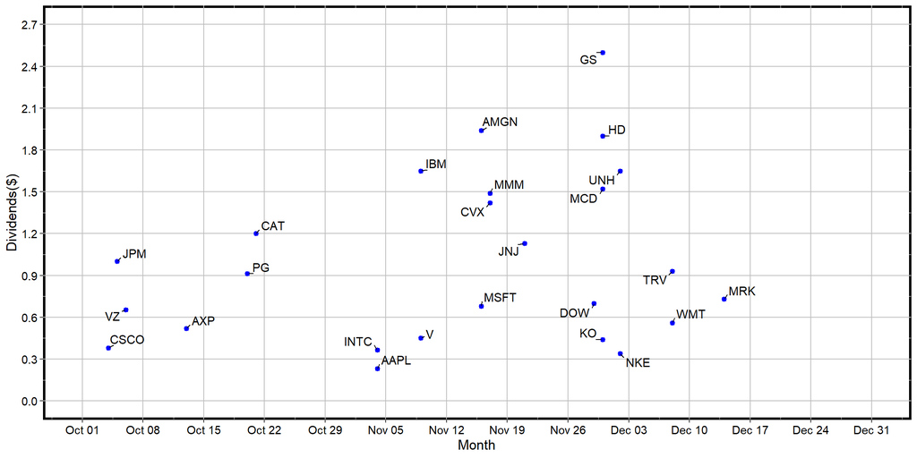

Last Dividends Paid in 2022 by Top 25 DOW30 Companies

```r
RplotterPkg::create_scatter_plot(
  df = dividends_last_2022_dt,
  aes_x = "Date",
  aes_y = "Dividend",
  aes_label = "Symbol",
  aes_label_size = 4,
  x_title = "Month",
  y_title = "Dividends($)",
  x_limits = as.Date(c("2022-10-01", "2022-12-31")),
  x_major_breaks = seq(as.Date("2022-10-01"), as.Date("2022-12-31"), by="1 week"),
  x_date_labels = "%b %d",
  rot_y_tic_label = T,
  y_limits = c(0.0, 2.7),
  y_major_breaks = seq(0.0,2.7,0.3),
  pts_size = 1.2,
  pts_color = "blue",
  pts_fill = "blue",
  show_minor_grids = F
)
```

## 1.3 Compute the Total Annual Yield for 2022

The Total Annual Yield (TAY) is defined as the sum of total dividends in 2022 divided by the closing price on the first dividend date.

Find the first dividend for each company in 2022.

```r
first_dividend_2022_dt <- dividends_dt[Date > as.Date("2021-12-31"), .SD[1L], by = Symbol][order(-Dividend)] %>%
  data.table::setnames(old = "Dividend", new = "FirstDiv")
```

Find the sum of the total dividends in 2022.

```r
sum_dividend_2022_dt <- dividends_dt[Date > as.Date("2021-12-31"), lapply(.SD, sum), by = Symbol, .SDcols = "Dividend"][order(-Dividend)] %>%
.[, .(Symbol, TotalDiv = Dividend)]
```

Outer join both the “first” and “sum” data.tables.

```r
data.table::setkey(first_dividend_2022_dt, "Symbol")
data.table::setkey(sum_dividend_2022_dt, "Symbol")
tay_dividend_2022_dt <- first_dividend_2022_dt[sum_dividend_2022_dt]
```

Get the daily closing prices for the 25 companies

```r
prices_dt <- RstocksPkg::get_stock_prices(
  symbols = tay_dividend_2022_dt$Symbol,
  periodicity = "daily",
  from = "2022-01-01",
  to = "2022-03-30"
) %>%
  .[, .(Symbol, Date, Close)]
```

Outer join the closing prices with the `tay_dividends_2022_dt`.

```r
data.table::setkeyv(tay_dividend_2022_dt, cols = c("Symbol","Date"))
data.table::setkeyv(prices_dt, cols = c("Symbol","Date"))
tay_dividend_prices_dt <- prices_dt[tay_dividend_2022_dt]
```

Compute `TAY = (TotalDiv/Close) * 100`:

```r
tay_dividend_prices_dt <- tay_dividend_prices_dt[, TAY := (TotalDiv/Close)*100] %>%
.[order(-TAY)]
```

Plot the TAY.

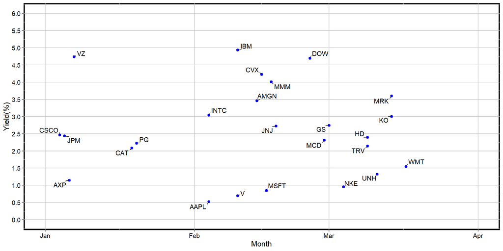

Total Annual Yield(TAY) of Dividends of top companies in 2022

```r
RplotterPkg::create_scatter_plot(
  df = tay_dividend_prices_dt,
  aes_x = "Date",
  aes_y = "TAY",
  aes_label = "Symbol",
  aes_label_size = 4,
  x_title = "Month",
  y_title = "Yield(%)",
  x_limits = as.Date(c("2022-01-01", "2022-04-01")),
  x_major_breaks = seq(as.Date("2022-01-01"), as.Date("2022-04-01"), by="1 month"),
  x_date_labels = "%b",
  rot_y_tic_label = TRUE,
  y_limits = c(0.0, 6.0),
  y_major_breaks = seq(0.0,6.0,0.5),
  pts_size = 1.2,
  pts_color = "blue",
  pts_fill = "blue",
  show_minor_grids = F
)
```

## 1.4 Dividends across the years

Add a *year* variable to `dividends_dt`.

```r
dividends_dt[, Year := as.numeric(format(Date, "%Y"))]
```

Compute the total yearly dividend payout for each company each year.

```r
dividends_yearly_dt <- dividends_dt[, lapply(.SD, sum), by = .(Symbol, Year),.SDcols = "Dividend"] %>%        data.table::setnames(old = "Dividend", new = "TotalDiv")
```

Create a column that shows increase/decrease from the previous year.

```r
dividends_yearly_dt <- dividends_yearly_dt[, DivIncrease := ifelse(TotalDiv > shift(TotalDiv,1), 1, 0)] %>%
  na.omit(cols = "DivIncrease")
```

Get the total increases for each company.

```r
dividend_increases_dt = dividends_yearly_dt[, lapply(.SD, sum), by = Symbol, .SDcols = "DivIncrease"] %>%
  data.table::setnames(old = "DivIncrease", new = "DivIncreaseTotal") %>%
  .[order(-DivIncreaseTotal)]
```

Plot the increases.

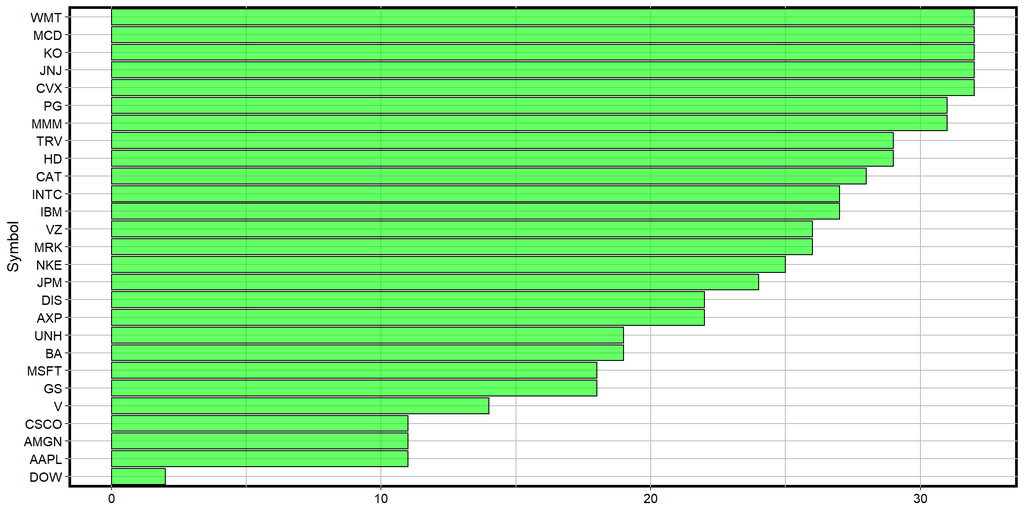

Total increases for each company

```r
RplotterPkg::create_bar_plot(
  df = dividend_increases_dt,
  aes_x = "Symbol",
  aes_y = "DivIncreaseTotal",
  do_coord_flip = T,
  rot_y_tic_label = T,
  y_title = "Years of Increase",
  order_bars = "asc",
  bar_fill = "green",
  bar_alpha = 0.6
)
```